# Visualization 2

Risa Dickerman

2026-10-13

```r
library(tidyverse)
library(p8105.datasets)
data("weather_df")
library(patchwork)

weather_df
```

```
## # A tibble: 2,190 × 6
##    name           id          date        prcp  tmax  tmin
##    <chr>          <chr>       <date>     <dbl> <dbl> <dbl>
##  1 CentralPark_NY USW00094728 2021-01-01   157   4.4   0.6
##  2 CentralPark_NY USW00094728 2021-01-02    13  10.6   2.2
##  3 CentralPark_NY USW00094728 2021-01-03    56   3.3   1.1
##  4 CentralPark_NY USW00094728 2021-01-04     5   6.1   1.7
##  5 CentralPark_NY USW00094728 2021-01-05     0   5.6   2.2
##  6 CentralPark_NY USW00094728 2021-01-06     0   5     1.1
##  7 CentralPark_NY USW00094728 2021-01-07     0   5    -1
##  8 CentralPark_NY USW00094728 2021-01-08     0   2.8  -2.7
##  9 CentralPark_NY USW00094728 2021-01-09     0   2.8  -4.3
## 10 CentralPark_NY USW00094728 2021-01-10     0   5    -1.6
## # ℹ 2,180 more rows
```

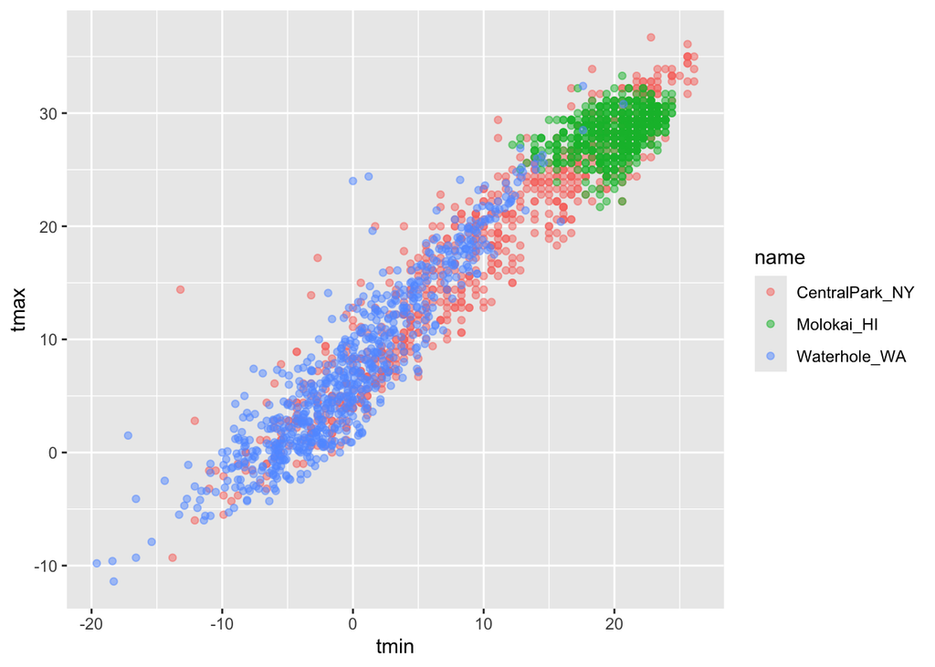

```r
weather_df |>
  ggplot(aes(x = tmin, y = tmax, color = name)) +
  geom_point(alpha = 0.5)
```

##Labels

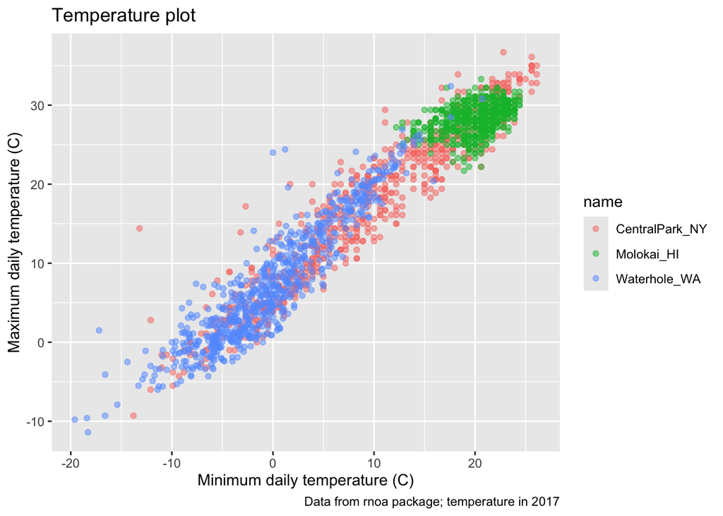

```r
weather_df |>
  ggplot(aes(x = tmin, y = tmax, color = name)) +
  geom_point(alpha = 0.5) +
  labs(
    title = "Temperature plot",
    x = "Minimum daily temperature (C)",
    y = "Maximum daily temperature (C)",
    caption = "Data from rnoa package; temperature in 2017"
  )
```

## Scales

gives you a way to have control Start with same plot

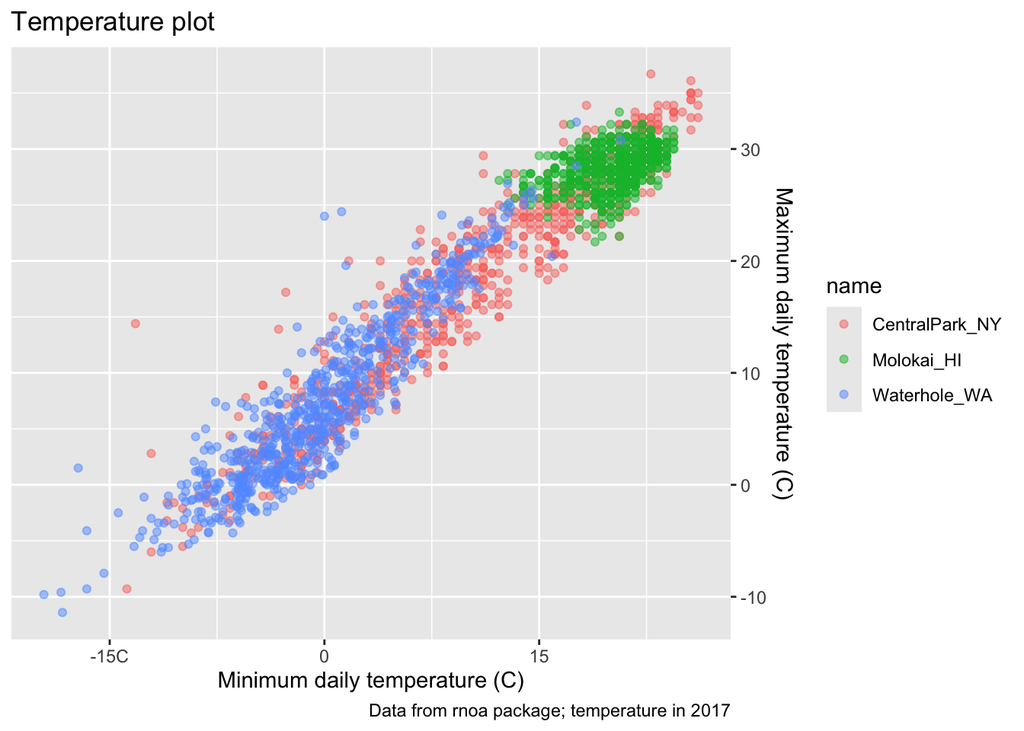

```r
weather_df |>
  ggplot(aes(x = tmin, y = tmax, color = name)) +
  geom_point(alpha = 0.5) +
  labs(
    title = "Temperature plot",
    x = "Minimum daily temperature (C)",
    y = "Maximum daily temperature (C)",
    caption = "Data from rnoa package; temperature in 2017"
  ) +
  scale_x_continuous(
    breaks = c(-15, 0, 15),
    labels = c("-15C", "0", "15")
  ) +
  scale_y_continuous (
    position = "right"
  )
```

```r
#don't want original spacing, scale_x allows you to change it
#scal_y lets you do a transformation of data: eg "sqrt", "log", or "right
```

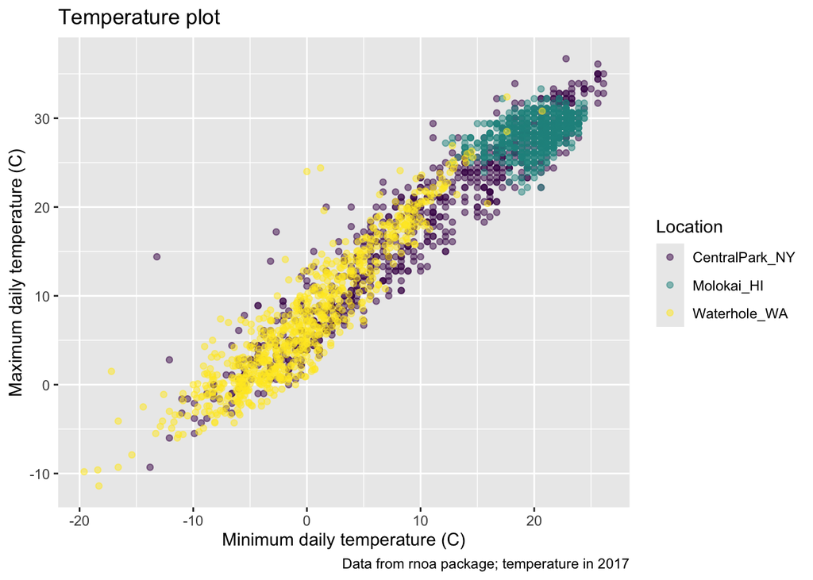

```r
weather_df |>
  ggplot(aes(x = tmin, y = tmax, color = name)) +
  geom_point(alpha = 0.5) +
  labs(
    title = "Temperature plot",
    x = "Minimum daily temperature (C)",
    y = "Maximum daily temperature (C)",
    caption = "Data from rnoa package; temperature in 2017") +
  scale_color_hue(
    name = "location") +
  viridis:: scale_color_viridis(
    name = "Location",
    discrete = TRUE
  )
```

```r
#Defined mapping between the color variable and the name
  #scale_color can edit color feature, can adjust hue
#scale_x - change title of caption
  #in scale if we want to change color of the name, can change caption to location (what all the locations are called)
#viridis package - scale color viridis assumes it is a continuous variable, have to specify discrete
  #viridis pallet: if you show this to someone who is color blind, it will be more accessible to them.
```

#Themes Where this lies on my plot doesn’t depend on difference between variable and color, just absent of data Grey background and white lines dont depend on data, just has to do with overall plot structure and appearance or theme

Shift the legend:

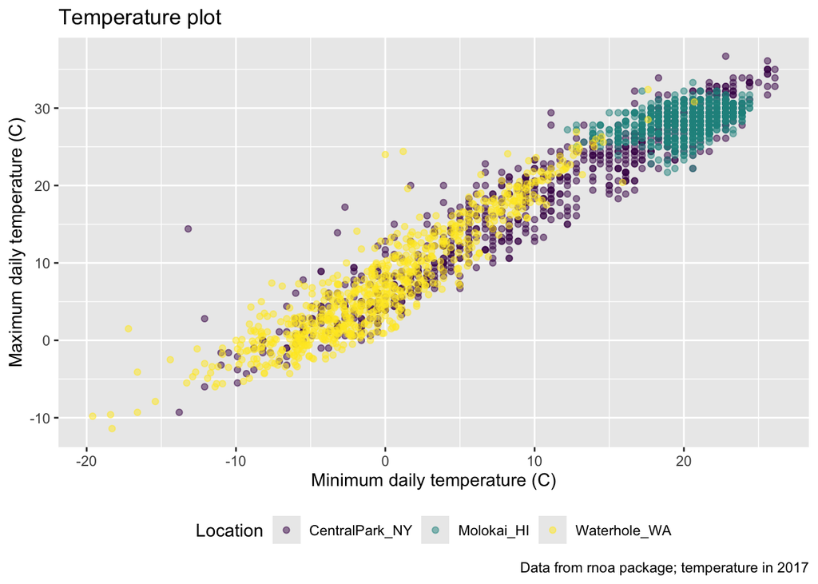

```r
weather_df |>
  ggplot(aes(x = tmin, y = tmax, color = name)) +
  geom_point(alpha = 0.5) +
  labs(
    title = "Temperature plot",
    x = "Minimum daily temperature (C)",
    y = "Maximum daily temperature (C)",
    caption = "Data from rnoa package; temperature in 2017") +
  scale_color_hue(
    name = "location") +
  viridis:: scale_color_viridis(
    name = "Location",
    discrete = TRUE
  ) +
  theme(legend.position = "bottom")
```

Change the overall theme - on default ggplot uses grey and white -in changing theme wipes the slate and makes it brand new, if want to do theme minimal have to do the theme first

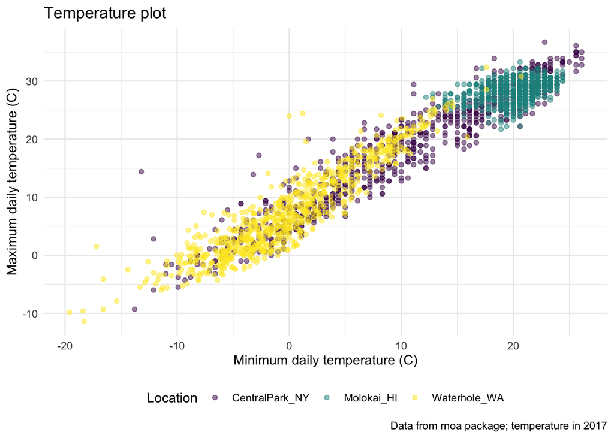

```r
weather_df |>
  ggplot(aes(x = tmin, y = tmax, color = name)) +
  geom_point(alpha = 0.5) +
  labs(
    title = "Temperature plot",
    x = "Minimum daily temperature (C)",
    y = "Maximum daily temperature (C)",
    caption = "Data from rnoa package; temperature in 2017") +
  scale_color_hue(
    name = "location") +
  viridis:: scale_color_viridis(
    name = "Location",
    discrete = TRUE
  ) +
  theme_minimal() +
  theme(legend.position = "bottom")
```

## Setting options

determine theme for every plot in document ggplot2.continuous. fill = “viridis” - will fill color for points later on all options ensure viridis color pallet and legend on bottom out.width shrinks it down a little bit: use this in the future of all markdowns to ensure that it will be there

```r
library(tidyverse)

knitr::opts_chunk$set(
  fig.width = 6,
  fig.asp = 0.6,
  out.width = "90%"
)

theme_set(theme_minimal() + theme(legend,position = "bottom"))

options(
  ggplot2.continuous.colour = "viridis",
  ggplot2.continuous.fill = "viridis"
)

scale_colour_discrete = scale_color_viridis_d
scale_colour_continuous = scale_color_viridis_d
```

## Data args in ‘geom’

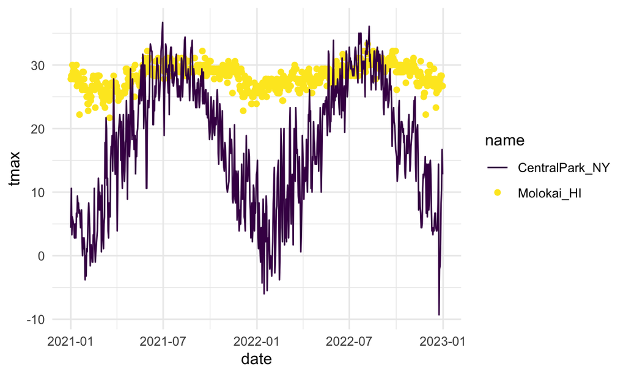

```r
central_park = weather_df |>
  filter(name == "CentralPark_NY")

waikiki = weather_df |>
  filter(name == "Molokai_HI")

ggplot(data = waikiki, aes(x = date, y = tmax, color = name)) +
  geom_point() +
  geom_line(data =central_park)
```

Use mostly for summary that is more complicated. Will create a separate dataset for each argument

## ‘Patchwork’

remember faceting? Creating the exact same plot. Create plot separately for each name putting a scatterplot next to a scatterplot is not possible with facceting

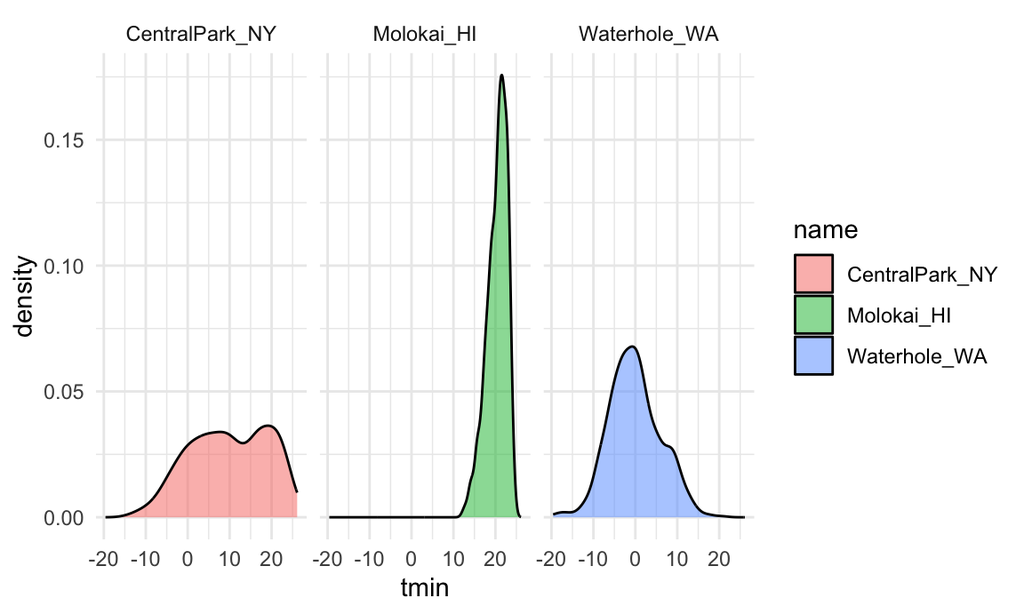

```r
weather_df |>
  ggplot(aes(x = tmin, fill = name)) +
  geom_density ( alpha = 0.5) +
  facet_grid(. ~ name)
```

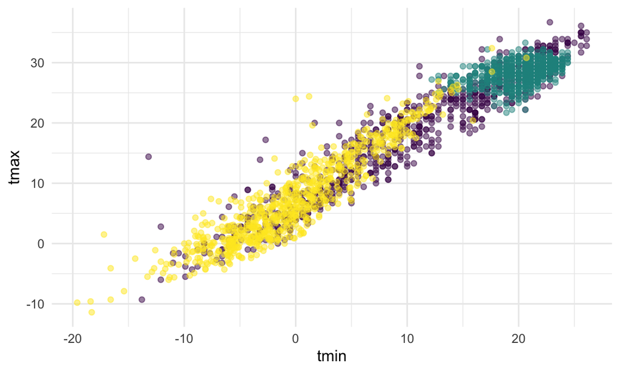

```r
tmax_tmin_p =
  weather_df |>
  ggplot(aes(x = tmin, y= tmax, color = name)) +
  geom_point(alpha = 0.5) +
  theme(legend.position = "none")
tmax_tmin_p
```

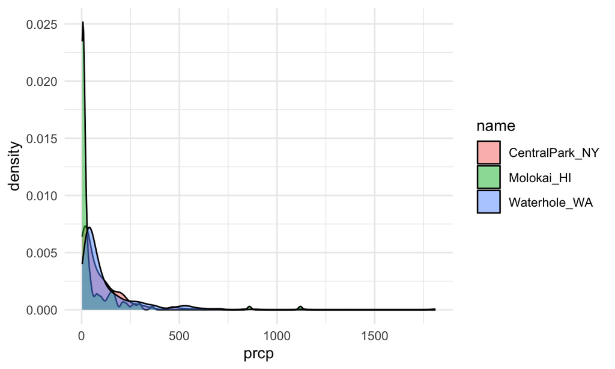

```r
prcp_dens_p =
  weather_df |>
  filter(prcp > 0) |>
  ggplot(aes(x = prcp, fill = name)) +
  geom_density(alpha = 0.5)
prcp_dens_p
```

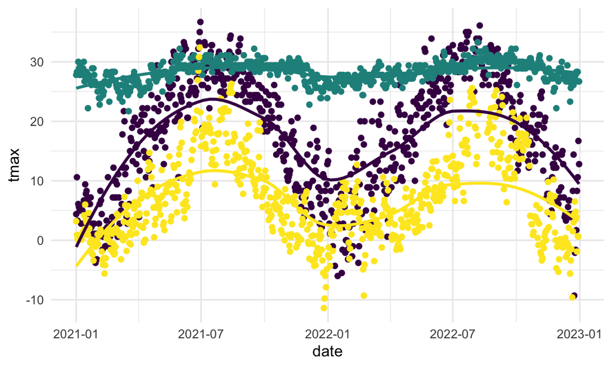

```r
tmax_date =
  weather_df |>
  ggplot(aes(x = date, y = tmax, color = name)) +
  geom_point() +
  geom_smooth(se = FALSE) +
  theme(legend.position = "none")
tmax_date
```

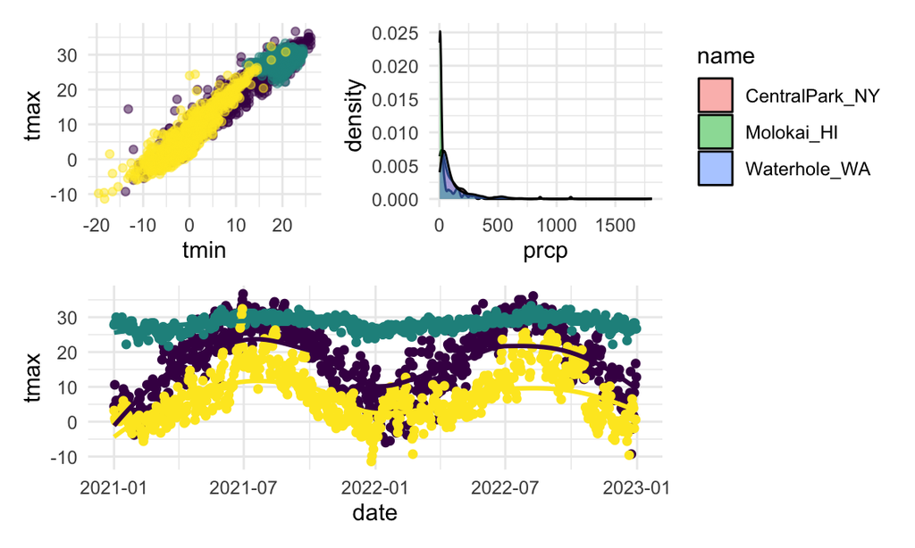

```r
(tmax_tmin_p + prcp_dens_p) / tmax_date
```

Create individual panels and use patchwork to join them.

## Data manipulation

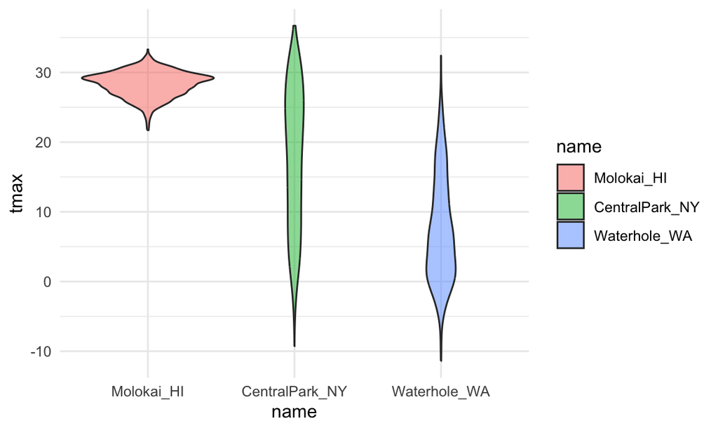

```r
weather_df |>
  mutate(
    name = factor(name),
    name = forcats::fct_relevel(name, c("Molokai_HI"))
  ) |>
  ggplot(aes(x = name, y = tmax, fill = name)) +
  geom_violin(alpha = 0.5)
```

going in alphabetical order by default due to convoluted reasons. To change that and put it in different order, want these to be factors and in particular order that I specify. Manipulate dataset first > changed name to factor: Central park - 1, Molokai - 2, etc.

If want to change order, do it by manipulating factor variable setting molokaki to first will make it factor number 1 > Central park -2 , etc.

Controlling factors is important

What if I want densities for tmin and tmax simultaneously. Want to create density plot with temperature, 1 density for 1 density of temps, 1 for another

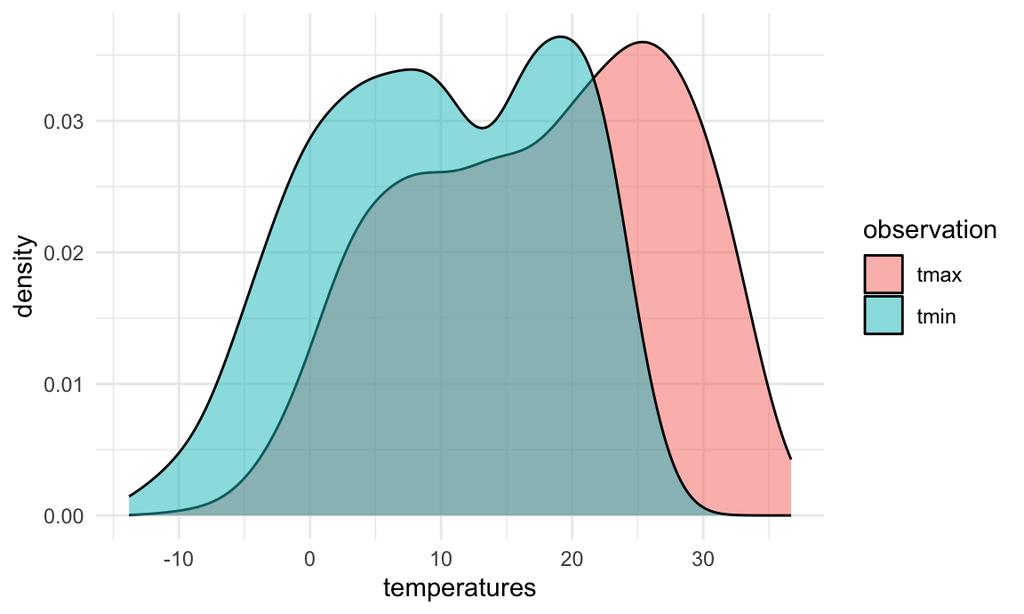

```r
weather_df |>
  filter(name == "CentralPark_NY") |>
  pivot_longer(
    tmax:tmin,
    names_to = "observation",
    values_to = "temperatures"
  ) |>
  ggplot(aes(x = temperatures, fill = observation)) +
  geom_density(alpha = 0.5)
```

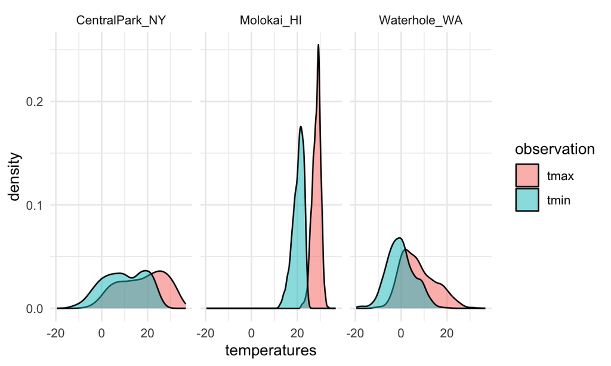

```r
weather_df |>
  pivot_longer(
    tmax:tmin,
    names_to = "observation",
    values_to = "temperatures"
  ) |>
  drop_na() |>
  ggplot(aes(x = temperatures, fill = observation)) +
  geom_density(alpha = 0.5) +
  facet_grid(. ~ name)
```